# 5243 Project 1

## **The Breif Introduction on Capitalism and Communism.**

[figure not shown]

#### Capitalism is defined as an economic system in which a country’s trade, industry, and profits are controlled only by private companies. The United States and most of the nations around the world are capitalist countries, but capitalism is not the only economic system available. Communism, on the other hand, advocating that goods are owned in common and are available to all as needed, means of production are owned communally.

#### **This report aims to 1.)help people understand the basic concepts of communism. 2.)explore insights between capitalism and communism.**

```r
getwd()
```

```r
##### Separate data sets into: capitalism, communism, Communist_Manifesto, lenin, Capital
docs =  read.csv("philosophy_data.csv",stringsAsFactors =  F)
capitalism  =
  docs %>% filter(school  == "capitalism")
communism  =
  docs %>% filter(school  == "communism")
Communist_Manifesto  =
  docs %>% filter(title  == "The Communist Manifesto")
lenin  =
  docs %>% filter(title  == "Essential Works Of Lenin")
Capital  =
  docs %>% filter(title  == "Capital")
```

### 1. Scratch the Surface of Capitalism

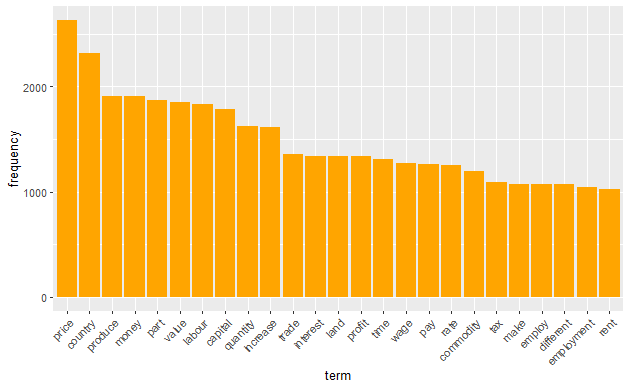

```r
################################################ Capitalism ############################################################

## data processing
words = Corpus(VectorSource(capitalism$lemmatized_str))
words = words %>%
  tm_map( removeNumbers)%>%
  tm_map( removePunctuation)%>%
  tm_map( removeWords, c("the", "and", "PRON", stopwords("english"))) %>% # Remove PRON
  tm_map( removeWords, c("must", "however", "two", "one", "upon", "much", "every", "either", "must", "can","may","therefore","will", "good","great", stopwords("english")))%>%
  tm_map( stripWhitespace)

### Document matrix 1
words_dtm <- DocumentTermMatrix(words)
### Document matrix 2
words_dtm_tfidf <- DocumentTermMatrix(words, control = list(weighting = weightTfIdf))
words_dtm_tfidf = removeSparseTerms(words_dtm_tfidf, 0.95)


## creating freq data frame
freq = data.frame(sort(colSums(as.matrix(words_dtm)), decreasing=TRUE))
table = data.frame(term = row.names(freq), frequency= freq)
colnames(table) = c('term', 'frequency')

# Bar chart
capitalism_chart<-ggplot(data= subset(table, frequency >1000), aes(x=reorder(term, -frequency), y=frequency)) +
  geom_bar(stat="identity", fill="orange")+ theme(axis.text.x = element_text(angle = 45,hjust=1) ) +labs(x ="term")
capitalism_chart
```

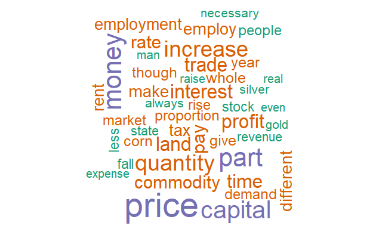

```r
## First word cloud
wordcloud(rownames(freq), freq[,1], max.words=50, colors=brewer.pal(1, "Dark2"))
```

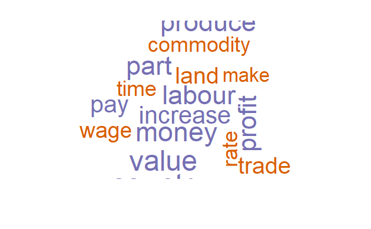

```r
### Second Word Cloud
freq.capitalism = data.frame(sort(colSums(as.matrix(words_dtm_tfidf)), decreasing=TRUE))
wordcloud(rownames(freq.capitalism), freq.capitalism[,1], max.words=50, colors=brewer.pal(1, "Dark2"))
```

```r
NA
NA
NA
NA
```

#### The first frequency graph shows the words appears more than 1000 times. The second graph is a overall wordcloud, while the last graph is a wordcloud based on [TF-IDF] which measures the relative importance of a word.

#### Words such as capital, employment, commodity, profit, money, and etc. are heavily mentionly in the School of Capitalism. Most of those words also happen to appearin the School of Communism, and we will introduce what do communists think of these terms later in this report.

#### As we mentioned earlier, most of the nations in the world are capilist. However, it is worthy to get to known a different system too. In order to better understand communism, what aspect should we pay attention to? We will start with some of the most frequent termnologies appears in communist studies.

[figure not shown]

```r
################################################   Communism:  ############################################################
## data processing
words = Corpus(VectorSource(capitalism$lemmatized_str))
words = tm_map(words, removeNumbers)
words = tm_map(words, removePunctuation)
words = tm_map(words, removeWords, c("the", "and", "PRON", stopwords("english"))) # Remove PRON
words = tm_map(words, removeWords, c("must", "however", "two", "one", "upon", "much", "every", "either", "must", "can","may","therefore","will", "good","great", stopwords("english")))
words = tm_map(words, removeWords, c("even", "always", "whole", stopwords("english")))
words = tm_map(words, removeWords, c("make", "always", "whole", stopwords("english")))
words =  tm_map(words, stripWhitespace)

### Document matrix1
words_dtm <- DocumentTermMatrix(words)
words_dtm_tfidf <- DocumentTermMatrix(words, control = list(weighting = weightTfIdf))
### Document matrix 2
words_dtm_tfidf = removeSparseTerms(words_dtm_tfidf, 0.95)



## creating freq data frame
freq = data.frame(sort(colSums(as.matrix(words_dtm)), decreasing=TRUE))
table = data.frame(term = row.names(freq), frequency= freq)
colnames(table) = c('term', 'frequency')


# Bar chart
communism_chart<-ggplot(data= subset(table, frequency >1000), aes(x=reorder(term, -frequency), y=frequency)) +
  geom_bar(stat="identity", fill="orange")+ theme(axis.text.x = element_text(angle = 45,hjust=1) ) + labs(x ="term")
communism_chart
```

[figure not shown]

```r
## First word cloud
wordcloud(rownames(freq), freq[,1], max.words=50, colors=brewer.pal(1, "Dark2"))
```

[figure not shown]

```r
### Second Word Cloud
freq.communism = data.frame(sort(colSums(as.matrix(words_dtm_tfidf)), decreasing=TRUE))
wordcloud(rownames(freq.communism), freq.communism[,1], max.words=100, colors=brewer.pal(1, "Dark2"))
```

```r
NA
NA
NA
NA
```

#### **Question: what does communism think of these terms?**

#### Money: There is no government or private property or currency, and the wealth is divided among citizens equally or according to individual need

#### Capital: Marxists define capital as “a social, economic relation” between people (rather than between people and things). In this sense they seek to abolish capital.

#### Land: Under communism, land is seen as property. All property is communally owned, and each person receives a portion based on what they need.

#### Commodity: In Marx’s theory, a commodity is something that is bought and sold, or exchanged in a relationship of trade. It has value, which represents a quantity of human labor.

#### Capitalism: Karl Marx saw capitalism as a progressive historical stage that would eventually be followed by socialism. Class conflict derives in capitalism because the proletariat are exploited in the system.

#### **Frequency Table of Book Titles**

| title | number_year |
| --- | --- |
| Capital | 12996 |
| Essential Works Of Lenin | 4469 |
| The Communist Manifesto | 493 |

#### Above table shows number of sentences in 3 books introducing communism. Since all 3 books have different length, one overall wordcloud graph may not be representive. Thus, we need to explore more!!!

[figure not shown]

```r
################################################   Communist_Manifesto  ############################################################
## data preprocessing
words = Corpus(VectorSource(Capital$lemmatized_str))
words = words %>%
  tm_map( removeNumbers)%>%
  tm_map( removePunctuation)%>%
  tm_map( removeWords, c("the", "and", "PRON", stopwords("english"))) %>% # Remove PRON
  tm_map( removeWords, c("must", "however", "two", "one", "upon", "much", "every", "either", "must", "can","may","therefore","will", "good","great", stopwords("english")))%>%
  tm_map(removeWords, c("even", "always", "whole", stopwords("english")))%>%
  tm_map(stripWhitespace)



### Document matirx
words_dtm <- DocumentTermMatrix(words)
words_dtm_tfidf <- DocumentTermMatrix(words, control = list(weighting = weightTfIdf))
### Document matrix 2
words_dtm_tfidf = removeSparseTerms(words_dtm_tfidf, 0.95)
words_dtm_tfidf
## creating freq data frame
freq = data.frame(sort(colSums(as.matrix(words_dtm)), decreasing=TRUE))
table = data.frame(term = row.names(freq), frequency= freq)
colnames(table) = c('term', 'frequency')


# Bar chart
communism_chart<-ggplot(data= subset(table, frequency >1000), aes(x=reorder(term, -frequency), y=frequency)) +
  geom_bar(stat="identity", fill="orange")+ theme(axis.text.x = element_text(angle = 45,hjust=1) )
communism_chart
```

[figure not shown]

```r
## First word cloud
wordcloud(rownames(freq), freq[,1], max.words=50, colors=brewer.pal(1, "Dark2"))
```

[figure not shown]

```r
### Second Word Cloud
freq.Manifesto = data.frame(sort(colSums(as.matrix(words_dtm_tfidf)), decreasing=TRUE))
wordcloud(rownames(freq.Manifesto), freq.Manifesto[,1], max.words=100, colors=brewer.pal(1, "Dark2"))
```

#### bourgeois: bourgeoisie, the social order that is dominated by the so-called middle class. In Marxist theory, the bourgeoisie plays a heroic role by revolutionizing industry and modernizing society. However, it also seeks to monopolize the benefits of this modernization by exploiting the propertyless proletariat

#### proletariat: the lowest or one of the lowest economic and social classes in a society.The proletariat is that class in society which lives entirely from the sale of its labor and does not draw profit from any kind of capital

#### class: The two classes are the proletariat (the working class), who make up the majority of the population within society and must work to survive, and the bourgeoisie (the capitalist class), a small minority who derives profit from employing the working class–(Wikipedia)

### 2.2 Check the Second Communism Related Book:Essential Works of Lenin

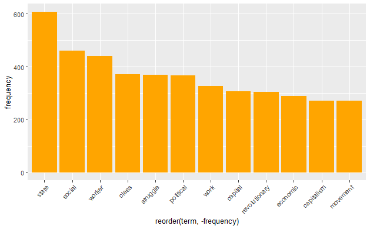

#### Imperialism: Lenin thought that imperialism was the “highest stage” of capitalism. He says that modern imperialism is different from ancient and medieval imperialism. Modern imperialism is mainly subject to economic considerations which is a method of exploitation.

#### Monopoly: A monopoly is defined as a single seller or producer that excludes competition from providing the same product. A monopoly can dictate price changes and creates barriers for competitors to enter the marketplace. Communists oppose monopoly.

#### Work class: There are two classes, proletariat (the working class) and capital class. Communists concern the struggle of the working class

#### revolution: Lenin exhorted all oppressed nations of the world to unite against their oppressors and play the role of the revolutionary proletariat against oppressive, capitalist nations. Lenin wanted Communist political parties in every country to lead the revolution. The Russian Revolution (1917) established the modern world’s first socialist state – the Union of Socialist Soviet Republics.

### Check the Third Communism Related Book: Capital: (资本论)

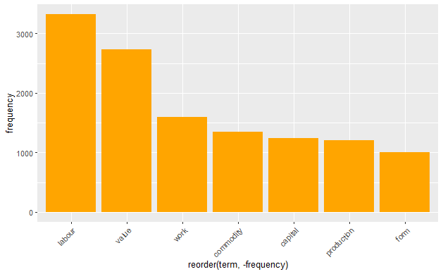

```r
################################################   Capital  ############################################################
## data reprocessing


words = Corpus(VectorSource(Capital$lemmatized_str))
words = words %>%
  tm_map( removeNumbers)%>%
  tm_map( removePunctuation)%>%
  tm_map( removeWords, c("the", "and", "PRON", stopwords("english"))) %>% # Remove PRON
  tm_map( removeWords, c("must", "however", "two", "one", "upon", "much", "every", "either", "must", "can","may","therefore","will", "good","great", stopwords("english")))%>%
  tm_map(removeWords, c("even", "always", "whole", stopwords("english")))%>%
  tm_map(stripWhitespace)




### Document matirx
words_dtm <- DocumentTermMatrix(words)
words_dtm_tfidf <- DocumentTermMatrix(words, control = list(weighting = weightTfIdf))
### Document matrix 2
words_dtm_tfidf = removeSparseTerms(words_dtm_tfidf, 0.95)

## creating freq data frame
freq = data.frame(sort(colSums(as.matrix(words_dtm)), decreasing=TRUE))
table = data.frame(term = row.names(freq), frequency= freq)
colnames(table) = c('term', 'frequency')

# Bar chart
Capital_chart<-ggplot(data= subset(table, frequency >1000), aes(x=reorder(term, -frequency), y=frequency)) +
  geom_bar(stat="identity", fill="orange")+ theme(axis.text.x = element_text(angle = 45,hjust=1) )
Capital_chart
```

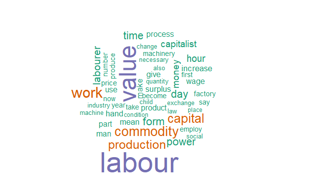

```r
## First word cloud
wordcloud(rownames(freq), freq[,1], max.words=50, colors=brewer.pal(1, "Dark2"))
```

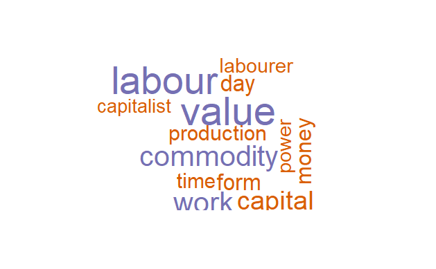

```r
### Second Word Cloud
freq.Capital = data.frame(sort(colSums(as.matrix(words_dtm_tfidf)), decreasing=TRUE))
wordcloud(rownames(freq.Capital), freq.Capital[,1], max.words=100, colors=brewer.pal(1, "Dark2"))
```

#### Based on the word cloud graph generated from book Capital, the book Capital shares similar terms with previous books. However, Capital has a lot of sentences related to the word **Labour/Labourer**

#### Labourer: Marx held that, in capitalism, labour was merely a commodity: in exchange for work, a labourer would receive a subsistence wage.

### Sentiment analysis

**Sentiment comparison between capitalism and Communism**

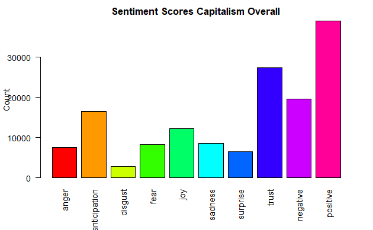

```r
#########################################   Communism:  ######################################
## sentiments score for capitalism
capitalism.score <- iconv(capitalism$lemmatized_str)
capitalism.sent <- get_nrc_sentiment(capitalism.score)

barplot(colSums(capitalism.sent),
        las = 2,
        col = rainbow(10),
        ylab = 'Count',
        main = 'Sentiment Scores Capitalism Overall')
```

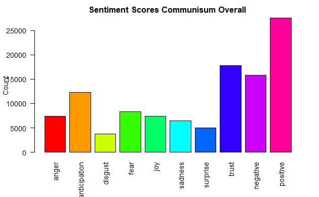

```r
##########################################   Communism:  ######################################
#### sentiment score
communism_score <- iconv(communism$lemmatized_str)
communism_sent<- get_nrc_sentiment(communism_score)


barplot(colSums(communism_sent),
        las = 2,
        col = rainbow(10),
        ylab = 'Count',
        main = 'Sentiment Scores Communisum Overall')
```

```r
NA
NA
NA
```

```r
capitalism_rate = as.numeric(colSums(capitalism.sent)[9]/colSums(capitalism.sent)[10])
capitalism_rate
```

```
[1] 0.5009868
```

```r
communism_rate = as.numeric(colSums(communism_sent)[9]/colSums(communism_sent)[10])
communism_rate
```

```
[1] 0.5724233
```

#### After comparing the propotions of counts of negative words. We see that, overall, books from school of communism has higher negative rate

**Sentiment Comparison Among Communism Books*

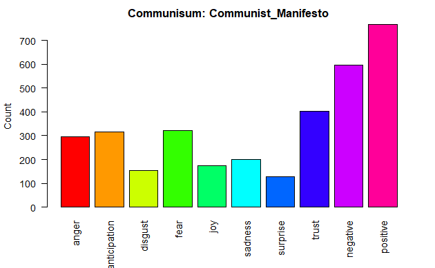

```r
###########################################  Communist_Manifesto  #####################
freq.Manifesto_score <- iconv(Communist_Manifesto$lemmatized_str)
Manifesto.sent<- get_nrc_sentiment(freq.Manifesto_score)

################################################   lenin  #############################
lenin.score <- iconv(lenin$lemmatized_str)
lenin.sent<- get_nrc_sentiment(lenin.score)
################################################   Capital  ###########################
#### sentiment score
Capital.score <- iconv(lenin$lemmatized_str)
Capital.sent<- get_nrc_sentiment(Capital.score)




###########################################  Communist_Manifesto  #####################
barplot(colSums(Manifesto.sent),
        las = 2,
        col = rainbow(10),
        ylab = 'Count',
        main = 'Communisum: Communist_Manifesto')
```

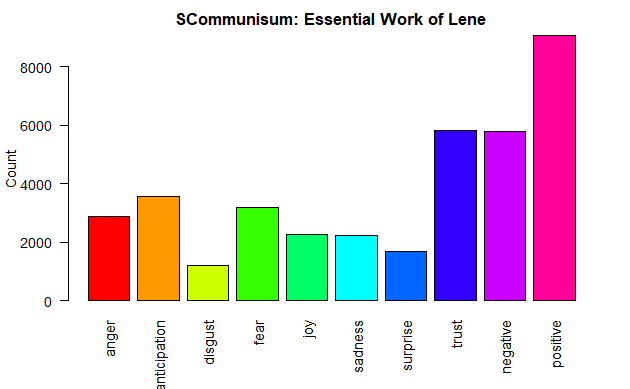

```r
################################################   lenin  #############################
barplot(colSums(lenin.sent),
        las = 2,
        col = rainbow(10),
        ylab = 'Count',
        main = 'SCommunisum: Essential Work of Lene')
```

[figure not shown]

```r
################################################   Capital  ###########################
barplot(colSums(Capital.sent),
        las = 2,
        col = rainbow(10),
        ylab = 'Count',
        main = 'Communisum: Capital')
```

**Take a brief look on which sentences in Communist Manifesto express anger and joy**

```r
Communist_Manifesto[Manifesto.sent$anger >5,]$sentence_spacy[1]
```

```
[1] "It proved, incontrovertibly, the disastrous effects of machinery and division of labour; the concentration of capital and land in a few hands; overproduction and crises; it pointed out the inevitable ruin of the petty bourgeois and peasant, the misery of the proletariat, the anarchy in producti…
```

```r
Communist_Manifesto[Manifesto.sent$joy >3,]$sentence_spacy[1]
```

```
[1] "By this, the long wished for opportunity was offered to True Socialism of confronting the political movement with the Socialist demands, of hurling the traditional anathemas against liberalism, against representative government, against bourgeois competition, bourgeois freedom of the press, bou…
```

```r
lenin[lenin.sent$anger >8,]$sentence_spacy[1]
```

```
[1] "During the lifetime of great revolutionaries, the oppressing classes relentlessly persecute them, and treat their teachings with malicious hostility, the most furious hatred and the most unscrupulous campaign of lies and slanders."
```

```r
lenin[lenin.sent$joy >5,]$sentence_spacy[2]
```

```
[1] "In these pamphlets, leg and illegal material should be collected and grouped systematically, on conditions of labor in a given trade, on the various conditions prevailing in the various parts of Russia, on the principal demands advanced by the workers in a given trade, on the defects of the law…
```

```r
Capital[Capital.sent$anger >9,]$sentence_spacy[2]
```

[output not shown]

```r
Capital[Capital.sent$joy >4,]$sentence_spacy[1]
```

```
[1] "The two fold social character of the labour of the individual appears to him, when reflected in his brain, only under those forms which are impressed upon that labour in every day practice by the exchange of products."
```

- Wrote at the end, it is hard to believe that there is a perfect social system works perfectly for all. However, it’s worth time to learn from different social system and maintain the good communication. We are living in world with a diversity of species, people, cultures, and social systems. Wish us a harmonies, peaceful, and non-violent world

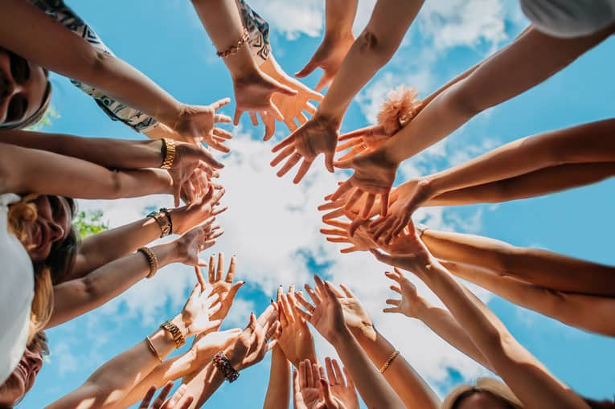